# Roteiro de Projeto 🎞️

#### Valores Discrepantes 📤

"In statistics, an outlier is a data point that differs significantly from other observations."

Um valor discrepante (*outlier*) pode ser

- uma variabilidade na medição,
- uma indicação de um dado real que destoa; ou
- resultado de um erro experimental (fatores não controlados que causam variação).
  - o último pode ser excluído do conjunto de dados.

Iniciamos por detectar visualmente os valores discrepantes de cada característica/variável.

👉 Escolheremos 4 características/variáveis para não poluir a figura.

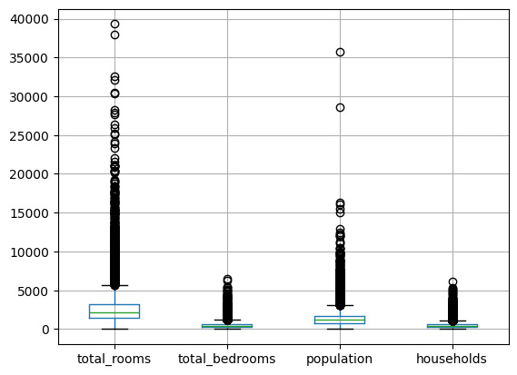

```python
X_treino_num[['total_rooms', 'total_bedrooms', 'population', 'households']].\
    boxplot();
```

Agora, vamos descartar valores discrepantes com `IsolationForest`.

```python
from sklearn.ensemble import IsolationForest

isolation_forest = IsolationForest()
outlier_pred = isolation_forest.fit_predict(X_treino_num)
```

```python
X_treino_num_sem_outlier = X_treino_num.iloc[outlier_pred == 1]
y_treino_num_sem_outlier = y_treino.iloc[outlier_pred == 1]
```

👉 Vamos avaliar o resultado da eliminação de valores discrepantes.

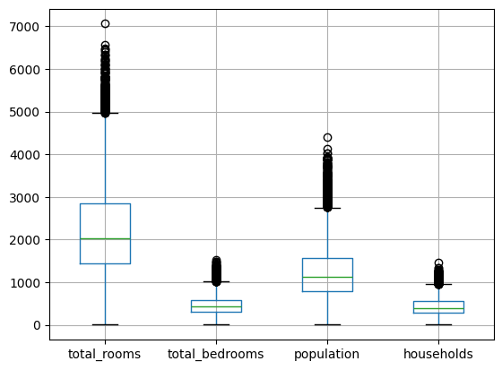

```python
X_treino_num_sem_outlier[['total_rooms', 'total_bedrooms',
                          'population', 'households']].\
    boxplot();
```

### Dados Textuais (e Categóricos) 💬

Anteriormente, desconsideramos o atributo categórico `ocean_proximity`

- por não ser numérico.

👉 Vamos considerá-lo neste tópico.

```python
X_treino_cat = df.select_dtypes(include=[np.object_]).\
    loc[X_treino.index]
X_treino_cat.head()
```

|  | ocean_proximity |
| --- | --- |
| 7400 | <1H OCEAN |
| 18611 | NEAR OCEAN |
| 12329 | INLAND |
| 943 | INLAND |
| 55 | NEAR BAY |

👉 A maioria dos algoritmos de Aprendizado de Máquina prefere trabalhar com números

- Vamos, então, converter as características/variáveis **categóricas** para **numéricas**.

#### Ordinal Encoding 1️⃣2️⃣3️⃣

"Ordinal encoding is a preprocessing technique used for converting categorical data into numeric values that preserve their inherent ordering."

##### Codificação

```python
from sklearn.preprocessing import OrdinalEncoder

oe = OrdinalEncoder()
X_treino_cat_oe = oe.fit_transform(X_treino_cat)
```

O codificador armazena os nomes das colunas codificadas

- no método `get_feature_names_out()`.

```python
X_treino_cat_oe = pd.DataFrame(X_treino_cat_oe,
                               columns=oe.get_feature_names_out(),
                               index=X_treino_cat.index)
X_treino_cat_oe.head()
```

|  | ocean_proximity |
| --- | --- |
| 7400 | 0.0 |
| 18611 | 4.0 |
| 12329 | 1.0 |
| 943 | 1.0 |
| 55 | 3.0 |

👉 Inspecione o resultado do processo de codificação (antes e depois).

```python
pd.concat([X_treino_cat, X_treino_cat_oe], axis='columns').\
    sample(frac=1).head()
```

|  | ocean_proximity | ocean_proximity |
| --- | --- | --- |
| 11908 | <1H OCEAN | 0.0 |
| 7654 | INLAND | 1.0 |
| 2124 | INLAND | 1.0 |
| 18270 | INLAND | 1.0 |
| 18887 | INLAND | 1.0 |

As categorias que representam cada ordinal é preservada no atributo `categories_`.

👉 Por padrão, o `OrdinalEncoder` codifica as categorias em ordem alfabética.

```python
oe.categories_
```

```
[array(['<1H OCEAN', 'INLAND', 'ISLAND', 'NEAR BAY', 'NEAR OCEAN'],
       dtype=object)]
```

O processo é reversível e podemos decodificar com `inverse_transform`.

- O codificador armazena os nomes das colunas decodificadas
- no atributo `feature_names_in_`.

```python
pd.DataFrame(oe.inverse_transform(X_treino_cat_oe),
             columns=oe.feature_names_in_,
             index=X_treino_cat.index).head()
```

|  | ocean_proximity |
| --- | --- |
| 7400 | <1H OCEAN |
| 18611 | NEAR OCEAN |
| 12329 | INLAND |
| 943 | INLAND |
| 55 | NEAR BAY |

🚨 O problema da representação do `OrdinalEncoder` ocorre quando 🚨

- algoritmos de Aprendizado de Máquina assumem que
- dois valores próximos são mais parecidos do que dois valores distantes.

👉 Nem sempre é problema, como é o caso de categorias ordenadas.

- e.g., "péssimo", "ruim", "regular", "bom" e "excelente".

#### OneHot Encoding 0️⃣1️⃣

"Categorical data can be either nominal or ordinal.

- Ordinal data has a ranked order for its values and can therefore be converted to numerical data through ordinal encoding;
- one-hot encoding is often applied to nominal variables, in order to improve the performance of the algorithm."

*One-hot encoding* cria um atributo binário por categoria.

- apenas um atributo será igual a 1 (*hot*),
- enquanto os outros serão 0 (*cold*).

```python
from sklearn.preprocessing import OneHotEncoder

ohe = OneHotEncoder()
X_treino_cat_ohe = ohe.fit_transform(X_treino_cat)
```

🚨 A saída é uma matriz esparsa SciPy 🚨

- armazenamos apenas a localização dos elementos $\neq 0$.

👉 muito útil quando possuimos atributos categóricos com milhares de categorias.

```python
X_treino_cat_ohe
```

```
<Compressed Sparse Row sparse matrix of dtype 'float64'
	with 16512 stored elements and shape (16512, 5)>
```

👉 Use o método `toarray()`, se quiser convertê-la em uma matriz (densa) NumPy

```python
X_treino_cat_ohe.toarray()
```

```
array([[1., 0., 0., 0., 0.],
       [0., 0., 0., 0., 1.],
       [0., 1., 0., 0., 0.],
       ...,
       [1., 0., 0., 0., 0.],
       [0., 1., 0., 0., 0.],
       [1., 0., 0., 0., 0.]], shape=(16512, 5))
```

O codificador armazena os nomes das colunas codificadas

- no método `get_feature_names_out()`.

```python
X_treino_cat_ohe = pd.DataFrame(X_treino_cat_ohe.toarray(),
                                columns=ohe.get_feature_names_out(),
                                index=X_treino_cat.index)
X_treino_cat_ohe.head()
```

|  | ocean_proximity_<1H OCEAN | ocean_proximity_INLAND | ocean_proximity_ISLAND | ocean_proximity_NEAR BAY | ocean_proximity_NEAR OCEAN |
| --- | --- | --- | --- | --- | --- |
| 7400 | 1.0 | 0.0 | 0.0 | 0.0 | 0.0 |
| 18611 | 0.0 | 0.0 | 0.0 | 0.0 | 1.0 |
| 12329 | 0.0 | 1.0 | 0.0 | 0.0 | 0.0 |
| 943 | 0.0 | 1.0 | 0.0 | 0.0 | 0.0 |
| 55 | 0.0 | 0.0 | 0.0 | 1.0 | 0.0 |

👉 Inspecione o resultado do processo de codificação (antes e depois).

```python
pd.concat([X_treino_cat, X_treino_cat_ohe], axis='columns').\
    sample(frac=1).head()
```

|  | ocean_proximity | ocean_proximity_<1H OCEAN | ocean_proximity_INLAND | ocean_proximity_ISLAND | ocean_proximity_NEAR BAY | ocean_proximity_NEAR OCEAN |
| --- | --- | --- | --- | --- | --- | --- |
| 9219 | <1H OCEAN | 1.0 | 0.0 | 0.0 | 0.0 | 0.0 |
| 3798 | NEAR BAY | 0.0 | 0.0 | 0.0 | 1.0 | 0.0 |
| 5673 | <1H OCEAN | 1.0 | 0.0 | 0.0 | 0.0 | 0.0 |
| 5183 | NEAR OCEAN | 0.0 | 0.0 | 0.0 | 0.0 | 1.0 |
| 4019 | NEAR OCEAN | 0.0 | 0.0 | 0.0 | 0.0 | 1.0 |

As categorias que representam cada ordinal é preservada no atributo `categories_`

👉 Por padrão, o `OneHotEncoder` codifica as categorias em ordem alfabética.

```python
ohe.categories_
```

```
[array(['<1H OCEAN', 'INLAND', 'ISLAND', 'NEAR BAY', 'NEAR OCEAN'],
       dtype=object)]
```

O processo é reversível e podemos decodificar com `inverse_transform`

- O codificador armazena os nomes das colunas decodificadas
- no atributo `feature_names_in_`.

```python
pd.DataFrame(ohe.inverse_transform(X_treino_cat_ohe),
             columns=ohe.feature_names_in_,
             index=X_treino_cat.index).head()
```

|  | ocean_proximity |
| --- | --- |
| 7400 | <1H OCEAN |
| 18611 | NEAR OCEAN |
| 12329 | INLAND |
| 943 | INLAND |
| 55 | NEAR BAY |

🚨 O que ocorre se surge uma categoria em uma característica/variável

- em que o `OneHotEncoding` não foi treinado e não criou uma coluna específica?

```python
df_offshore = pd.DataFrame([['OFFSHORE']],
                           columns=ohe.feature_names_in_)
df_offshore
```

|  | ocean_proximity |
| --- | --- |
| 0 | OFFSHORE |

👉 Uma exceção será lançada:

- `ValueError: Found unknown categories ['OFFSHORE'] in column 0 during transform`

```python
# ohe.transform(df_offshore)
```

ℹ️ Solução. Podemos configurar o parâmetro `handle_unknown`para "ignore"

- irá representar a categoria desconhecida com $0$ nas categorias conhecidas

```python
ohe.handle_unknown = "ignore"
offshore_cat_ohe = ohe.transform(df_offshore).toarray()

pd.DataFrame(offshore_cat_ohe,
             columns=ohe.get_feature_names_out())
```

|  | ocean_proximity_<1H OCEAN | ocean_proximity_INLAND | ocean_proximity_ISLAND | ocean_proximity_NEAR BAY | ocean_proximity_NEAR OCEAN |
| --- | --- | --- | --- | --- | --- |
| 0 | 0.0 | 0.0 | 0.0 | 0.0 | 0.0 |

### Escala dos Dados 🧗🏾‍♀️

👉 A maioria dos algoritmos de Aprendizado de Máquina não funciona bem com

- dados (numéricos) de entrada em escalas muito diferentes.

🚨 A *Árvore de Decisão* é uma exceção 🚨

Veja como dados em escalas diferentes podem majorar um ao outro.

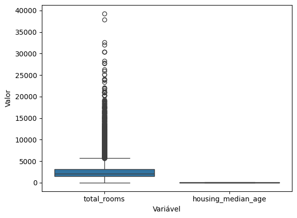

```python
df_melted = df[['total_rooms', 'housing_median_age']].\
    melt(var_name='Variável', value_name='Valor')
sns.boxplot(data=df_melted, x='Variável', y='Valor');
```

ℹ️ Solução. Há maneiras de colocar todos os atributos na mesma escala.

1. $\min-\max$ (normalização);
2. padronização (*$Z$-score normalization*); e
3. robusto.

#### $\min-\max$ (Normalização)

"Is the simplest method and consists in rescaling the range of features to scale the range in $[0, 1]$ or $[−1, 1]$."

$$x^\prime = \frac{x-\min(x)}{\max(x)-\min(x)}$$

```python
from sklearn.preprocessing import MinMaxScaler

mms = MinMaxScaler()
X_treino_num_mms = mms.fit_transform(X_treino_num)
```

O escalador armazena os nomes das colunas codificadas

- no método `get_feature_names_out()`.

```python
X_treino_num_mms = pd.DataFrame(X_treino_num_mms,
                                columns=mms.get_feature_names_out(),
                                index=X_treino.index)
X_treino_num_mms.head()
```

|  | longitude | latitude | housing_median_age | total_rooms | total_bedrooms | population | households | median_income |
| --- | --- | --- | --- | --- | --- | --- | --- | --- |
| 7400 | 0.622510 | 0.170032 | 0.862745 | 0.077929 | 0.102110 | 0.035988 | 0.102615 | 0.212445 |
| 18611 | 0.703187 | 0.054198 | 0.529412 | 0.029096 | 0.052297 | 0.018751 | 0.047854 | 0.183915 |
| 12329 | 0.283865 | 0.645058 | 0.078431 | 0.035429 | 0.057728 | 0.017798 | 0.052787 | 0.149970 |
| 943 | 0.520916 | 0.351753 | 0.705882 | 0.018668 | 0.025605 | 0.015724 | 0.022529 | 0.132191 |
| 55 | 0.206175 | 0.561105 | 1.000000 | 0.023984 | 0.037554 | 0.016060 | 0.036014 | 0.062854 |

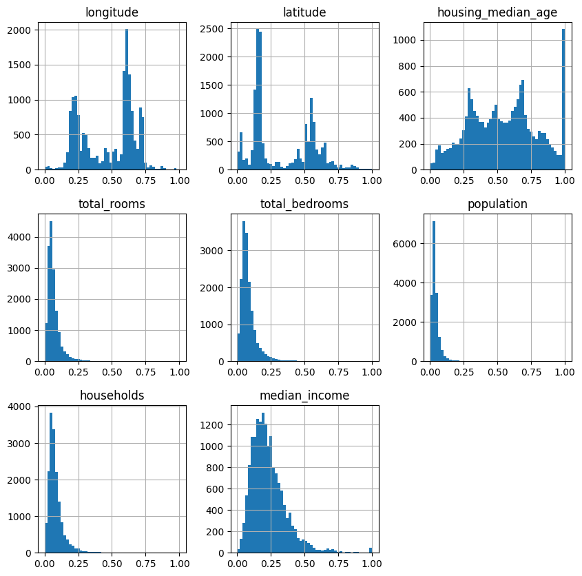

```python
X_treino_num_mms.hist(bins=50, figsize=(10, 10));
```

👉 redes neurais trabalham melhor com a entrada tendo média zero

- um intervalo de –1 a 1 é preferível.

$$x^{\prime\prime} = a + x^\prime (b-a),$$ em que $a$ e $b$ são os limites dos intervalos.

👉 para mudar o intervalo de $[0, 1]$ para $[a, b]$ basta usar

- o parâmetro `feature_range=(a, b)` na classe `MinMaxScaler`.

```python
from sklearn.preprocessing import MinMaxScaler

mms = MinMaxScaler(feature_range=(-1, 1))
X_treino_num_mms = mms.fit_transform(X_treino_num)
```

```python
X_treino_num_mms = pd.DataFrame(X_treino_num_mms,
                            columns=mms.get_feature_names_out(),
                            index=X_treino_num.index)
X_treino_num_mms.head()
```

|  | longitude | latitude | housing_median_age | total_rooms | total_bedrooms | population | households | median_income |
| --- | --- | --- | --- | --- | --- | --- | --- | --- |
| 7400 | 0.245020 | -0.659936 | 0.725490 | -0.844143 | -0.795779 | -0.928025 | -0.794771 | -0.575109 |
| 18611 | 0.406375 | -0.891605 | 0.058824 | -0.941808 | -0.895407 | -0.962499 | -0.904292 | -0.632171 |
| 12329 | -0.432271 | 0.290117 | -0.843137 | -0.929142 | -0.884544 | -0.964405 | -0.894425 | -0.700059 |
| 943 | 0.041833 | -0.296493 | 0.411765 | -0.962663 | -0.948790 | -0.968553 | -0.954942 | -0.735617 |
| 55 | -0.587649 | 0.122210 | 1.000000 | -0.952032 | -0.924891 | -0.967880 | -0.927972 | -0.874291 |

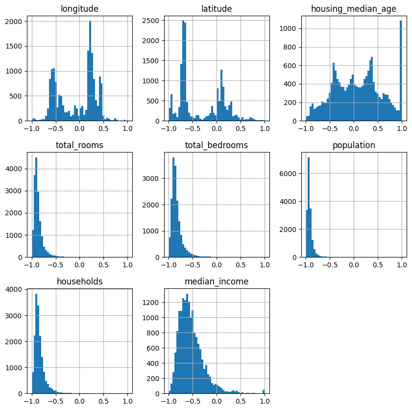

```python
X_treino_num_mms.hist(bins=50, figsize=(10, 10));
```

👉 vamos comparar, ao final,

- o efeito de cada escalador na presença de valores discrepantes

```python
exemplo = np.array([10, 12, 14, 15, 18, 22, 100]).reshape(-1, 1)
```

```python
from sklearn.preprocessing import MinMaxScaler

mms2 = MinMaxScaler()
exemplo_mms2 = mms2.fit_transform(exemplo)
```

```python
df_scale = pd.DataFrame(np.hstack([exemplo, exemplo_mms2]),
                        columns=['exemplo', 'MinMax'])
df_scale
```

|  | exemplo | MinMax |
| --- | --- | --- |
| 0 | 10.0 | 0.000000 |
| 1 | 12.0 | 0.022222 |
| 2 | 14.0 | 0.044444 |
| 3 | 15.0 | 0.055556 |
| 4 | 18.0 | 0.088889 |
| 5 | 22.0 | 0.133333 |
| 6 | 100.0 | 1.000000 |

#### Padronização (*$Z$-score normalization*)

"Feature standardization makes the values of each feature in the data have zero-mean (when subtracting the mean in the numerator) and unit-variance"

$$x^\prime=\frac{x - \bar{x}}{\sigma}$$

🚨 Padronização não restringe os valores a um intervalo específico 🚨

- como ocorria no $\min-\max$!

```python
from sklearn.preprocessing import StandardScaler

ss = StandardScaler()
X_treino_num_ss = ss.fit_transform(X_treino_num)
```

O escalador armazena os nomes das colunas codificadas

- no método `get_feature_names_out()`.

```python
X_treino_num_ss = pd.DataFrame(X_treino_num_ss,
                               columns=ss.get_feature_names_out(),
                               index=X_treino_num.index)
X_treino_num_ss.head()
```

|  | longitude | latitude | housing_median_age | total_rooms | total_bedrooms | population | households | median_income |
| --- | --- | --- | --- | --- | --- | --- | --- | --- |
| 7400 | 0.734002 | -0.699703 | 1.292087 | 0.195144 | 0.289083 | -0.121456 | 0.323790 | -0.152680 |
| 18611 | 1.137852 | -1.209825 | -0.055597 | -0.679994 | -0.472963 | -0.655181 | -0.539918 | -0.370152 |
| 12329 | -0.961171 | 1.392265 | -1.878934 | -0.566499 | -0.389874 | -0.684687 | -0.462106 | -0.628890 |
| 943 | 0.225450 | 0.100580 | 0.657883 | -0.866872 | -0.881286 | -0.748908 | -0.939350 | -0.764409 |
| 55 | -1.350063 | 1.022544 | 1.847016 | -0.771610 | -0.698490 | -0.738494 | -0.726666 | -1.292923 |

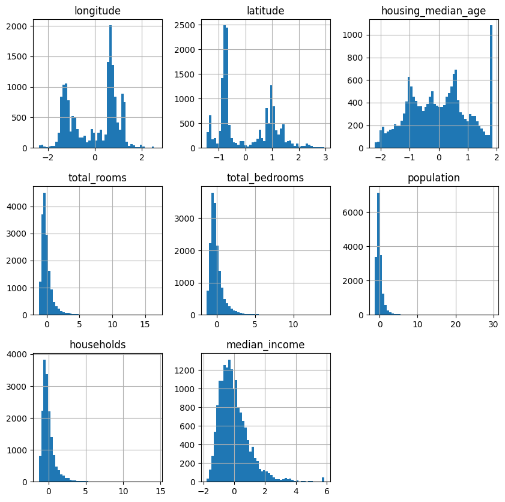

```python
X_treino_num_ss.hist(bins=50, figsize=(10, 10));
```

🚨 a padronização (em contraponto ao $\min-\max$)

- é menos afetada por valores discrepantes.

👉 vamos comparar, ao final,

- o efeito de cada escalador na presença de valores discrepantes

```python
from sklearn.preprocessing import StandardScaler

ss2 = StandardScaler()
exemplo_ss2 = ss.fit_transform(exemplo)
```

```python
df_scale['Standard'] = exemplo_ss2
df_scale
```

|  | exemplo | MinMax | Standard |
| --- | --- | --- | --- |
| 0 | 10.0 | 0.000000 | -0.577962 |
| 1 | 12.0 | 0.022222 | -0.511091 |
| 2 | 14.0 | 0.044444 | -0.444219 |
| 3 | 15.0 | 0.055556 | -0.410783 |
| 4 | 18.0 | 0.088889 | -0.310476 |
| 5 | 22.0 | 0.133333 | -0.176732 |
| 6 | 100.0 | 1.000000 | 2.431264 |

#### Robusto (a Valores Discrepantes)

"Robust scaling, also known as standardization using median and interquartile range (IQR), is designed to be robust to outliers."

$$x^\prime=\frac{x - Q_{2}(x)}{Q_{3}(x) - Q_{1}(x)},$$

em que $Q_{1}(x)$,$Q_{2}(x)$, $Q_{3}(x)$ são os 3 quartis (percentil 25, 50 e 75) da característica/variável.

```python
from sklearn.preprocessing import RobustScaler

rs = RobustScaler()
X_treino_num_rs = rs.fit_transform(X_treino_num)
```

```python
X_treino_num_rs = pd.DataFrame(X_treino_num_rs,
                           columns=rs.get_feature_names_out(),
                           index=X_treino.index)
X_treino_num_rs.head()
```

|  | longitude | latitude | housing_median_age | total_rooms | total_bedrooms | population | households | median_income |
| --- | --- | --- | --- | --- | --- | --- | --- | --- |
| 7400 | 0.102902 | -0.031662 | 0.842105 | 0.551026 | 0.646377 | 0.129204 | 0.661538 | 0.022504 |
| 18611 | 0.316623 | -0.319261 | -0.052632 | -0.575073 | -0.284058 | -0.527496 | -0.363077 | -0.167104 |
| 12329 | -0.794195 | 1.147757 | -1.263158 | -0.429032 | -0.182609 | -0.563801 | -0.270769 | -0.392690 |
| 943 | -0.166227 | 0.419525 | 0.421053 | -0.815543 | -0.782609 | -0.642819 | -0.836923 | -0.510845 |
| 55 | -1.000000 | 0.939314 | 1.210526 | -0.692962 | -0.559420 | -0.630005 | -0.584615 | -0.971641 |

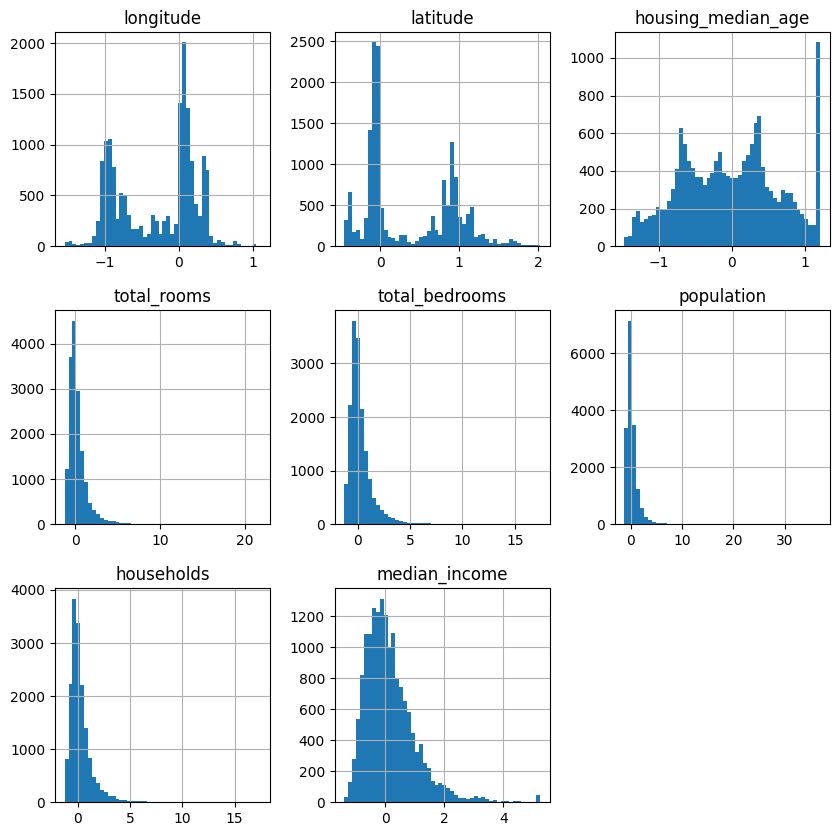

```python
X_treino_num_rs.hist(bins=50, figsize=(10, 10));
```

👉 vamos comparar, agora, o efeito de cada escalador na presença de valores discrepantes

```python
from sklearn.preprocessing import RobustScaler

rs2 = RobustScaler()
exemplo_rs2 = rs2.fit_transform(exemplo)
```

👉 veja que os valores estão cada vez menos próximos

```python
df_scale['Robust']= exemplo_rs2
df_scale
```

|  | exemplo | MinMax | Standard | Robust |
| --- | --- | --- | --- | --- |
| 0 | 10.0 | 0.000000 | -0.577962 | -0.714286 |
| 1 | 12.0 | 0.022222 | -0.511091 | -0.428571 |
| 2 | 14.0 | 0.044444 | -0.444219 | -0.142857 |
| 3 | 15.0 | 0.055556 | -0.410783 | 0.000000 |
| 4 | 18.0 | 0.088889 | -0.310476 | 0.428571 |
| 5 | 22.0 | 0.133333 | -0.176732 | 1.000000 |
| 6 | 100.0 | 1.000000 | 2.431264 | 12.142857 |

🚨 Os algoritmos de Aprendizado de Máquina **não** funcionam

- com os dados espremidos em um intervalo pequeno.🚨

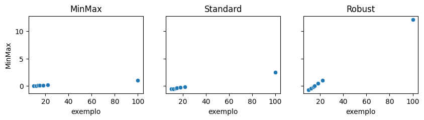

```python
fig, axs = plt.subplots(1, 3, figsize=(10, 2), sharey=True)

for i, scaler in enumerate([c for c in df_scale.columns
                            if c != 'exemplo']):
    sns.scatterplot(df_scale, x = "exemplo", y = scaler,
                    ax=axs[i]).set_title(scaler)
```

#### Cauda Longa como Ponto de Atenção

"*heavy-tailed* means the distribution decreases more slowly than an exponential distribution, so extreme values are more likely"

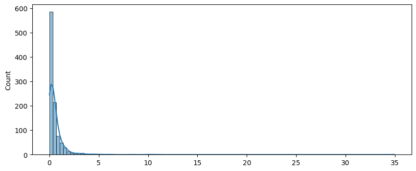

```python
plt.figure(figsize=(10, 4))
sns.histplot(np.random.pareto(a=3, size=1000), bins=100, kde=True);
```

Quando a cauda é realmente longa, os redimensionamentos dos dados irão

- espremer a maior parte dos dados em um intervalo pequeno.

🚨 Os algoritmos de Aprendizado de Máquina **não** funcionam

- com os dados espremidos em um intervalo pequeno.🚨

**Antes** de redimensionar os dados,

- devemos **primeiro** encolher a cauda longa; e
- se possível, tornar a distribuição praticamente simétrica.

ℹ️ Solução.

- substituir a característica/variável pela sua raíz quadrada
  - ou elevar a um potência entre 0 e 1; ou
- se a cauda for muito longa (e.g. distribuição seguir a lei de potência),
  - substituir a característica/variável pelo seu logaritmo.

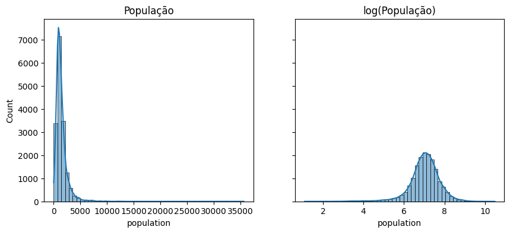

```python
fig, axs = plt.subplots(1, 2, figsize=(10, 4), sharey=True)

sns.histplot(X_treino, x="population", bins=50,
             ax=axs[0], kde=True).set_title("População")
sns.histplot(np.log(X_treino["population"]), bins=50,
             ax=axs[1], kde=True).set_title("log(População)");
```

### Transformadores Customizados

Scikit-Learn fornece diversos *transformers* úteis,

- mas em alguns casos é necessário criar transformadores personalizados.

Para transformações que não exigem treinamento,

- basta escrever uma função que:
  - Receba um *array* NumPy como entrada.
  - Retorne o *array* transformado.

```python
from sklearn.preprocessing import FunctionTransformer

log_transformer = FunctionTransformer(np.log, inverse_func=np.exp)
log_transformer
```

```
FunctionTransformer(func=<ufunc 'log'>, inverse_func=<ufunc 'exp'>)
```

```python
log_pop = log_transformer.transform(X_treino["population"])
log_pop
```

```
7400     7.160069
18611    6.510258
12329    6.458338
943      6.335054
55       6.356108
           ...
12861    6.942157
1131     8.067149
14448    7.047517
7292     6.508769
8514     7.866722
Name: population, Length: 16512, dtype: float64
```

### *Pipelines* 🪈

Existem muitas etapas de transformação de dados que precisam ser executadas

- na ordem correta.

[figure not shown]

Scikit-Learn fornece a classe `Pipeline` para ajudar

- com tais sequências de transformações

Vamos começar com um pequeno *pipeline* para os atributos numéricos.

- primeiro imputaremos, depois escalamos as características/variáveis de entrada;

[figure not shown]

Pipelines são:

- lista de pares de (nome, estimador) que definem uma sequência de etapas;
  - os nomes podem ser o que quisermos
    - (desde que únicos e não contenham sublinhados duplos "__");
  - os estimadores devem ser transformadores
    - i.e., devem ter um método `fit_transform()`,
    - exceto o último estimador, que pode ser qualquer coisa,
      - transformador, preditor
        - ou qualquer outro tipo de estimador.

[figure not shown]

Eis o pequeno *pipeline* para os atributos numéricos.

```python
from sklearn.pipeline import Pipeline

pipeline_num = Pipeline([
    ("impute", SimpleImputer(strategy="median")),
    ("standardize", StandardScaler()),
])
pipeline_num
```

```
Pipeline(steps=[('impute', SimpleImputer(strategy='median')),
                ('standardize', StandardScaler())])
```

Podemos acessar os estimadores por meio do atributo `named_steps`, um dicionário

```python
pipeline_num.named_steps
```

```
{'impute': SimpleImputer(strategy='median'), 'standardize': StandardScaler()}
```

```python
pipeline_num.named_steps["impute"]
```

```
SimpleImputer(strategy='median')
```

#### make_pipeline

👉 dica: se não quisermos nomear os transformadores,

- usamos o método `make_pipeline()`

```python
from sklearn.pipeline import make_pipeline

pipeline_num = make_pipeline(
    SimpleImputer(strategy="median"),
    StandardScaler()
)
pipeline_num
```

```
Pipeline(steps=[('simpleimputer', SimpleImputer(strategy='median')),
                ('standardscaler', StandardScaler())])
```

Com `make_pipeline()`, os nomes dos transformadores serão

- o nome da classe, em minúsculas e sem sublinhado

👉 se mais de um transformador tem o mesmo nome, um sufixo sequenciará os nomes

- e.g., "simpleimputer-1", "simpleimputer-2", etc.

```python
pipeline_num.named_steps
```

```
{'simpleimputer': SimpleImputer(strategy='median'),
 'standardscaler': StandardScaler()}
```

O que ocorre quando chamamos o método `fit()` de um *pipeline*?

- irá chamar o método `fit_transform()` sequencialmente
  - para cada transformador,
- passando a saída de cada chamada como parâmetro da próxima chamada;
- até que alcança o último estimador, que chama o método `fit()`.

O que ocorre quando chamamos o método `transform()` de um *pipeline*?

- irá chamar o método `transform()` sequencialmente para cada transformador,
- passando a saída de cada chamada como parâmetro da próxima chamada;
- até que alcança o último estimador, que chama o método `transform()`.

O que ocorre quando chamamos o método `predict()` de um *pipeline*?

- irá chamar o método `transform()` sequencialmente para cada transformador,
- passando a saída de cada chamada como parâmetro da próxima chamada;
- até que alcança o último estimador, que chama o método `predict()`.

🚨 Só é possível chamar um método do `pipeline`

- se o último estimador tem esse método.

[figure not shown]

Vamos chamar o método `fit_transform()` do *pipeline* que acabamos de criar

- para entender o mecanismo de funcionamento.

```python
X_treino_num_pipeline = pipeline_num.fit_transform(X_treino_num)
```

```python
X_treino_num_pipeline = pd.DataFrame(
    X_treino_num_pipeline,
    columns=pipeline_num.get_feature_names_out(),
    index=X_treino_num.index)

X_treino_num_pipeline.head()
```

|  | longitude | latitude | housing_median_age | total_rooms | total_bedrooms | population | households | median_income |
| --- | --- | --- | --- | --- | --- | --- | --- | --- |
| 7400 | 0.734002 | -0.699703 | 1.292087 | 0.195144 | 0.289083 | -0.121456 | 0.323790 | -0.152680 |
| 18611 | 1.137852 | -1.209825 | -0.055597 | -0.679994 | -0.472963 | -0.655181 | -0.539918 | -0.370152 |
| 12329 | -0.961171 | 1.392265 | -1.878934 | -0.566499 | -0.389874 | -0.684687 | -0.462106 | -0.628890 |
| 943 | 0.225450 | 0.100580 | 0.657883 | -0.866872 | -0.881286 | -0.748908 | -0.939350 | -0.764409 |
| 55 | -1.350063 | 1.022544 | 1.847016 | -0.771610 | -0.698490 | -0.738494 | -0.726666 | -1.292923 |

Equivalentemente,

```python
X_treino_num_pipeline = pipeline_num.named_steps['simpleimputer'].\
    fit_transform(X_treino_num)
X_treino_num_pipeline = pipeline_num.named_steps['standardscaler'].\
    fit_transform(X_treino_num_pipeline)
```

```python
X_treino_num_pipeline = pd.DataFrame(X_treino_num_pipeline,
                                     columns=pipeline_num.get_feature_names_out(),
                                     index=X_treino_num.index)

X_treino_num_pipeline.head()
```

|  | longitude | latitude | housing_median_age | total_rooms | total_bedrooms | population | households | median_income |
| --- | --- | --- | --- | --- | --- | --- | --- | --- |
| 7400 | 0.734002 | -0.699703 | 1.292087 | 0.195144 | 0.289083 | -0.121456 | 0.323790 | -0.152680 |
| 18611 | 1.137852 | -1.209825 | -0.055597 | -0.679994 | -0.472963 | -0.655181 | -0.539918 | -0.370152 |
| 12329 | -0.961171 | 1.392265 | -1.878934 | -0.566499 | -0.389874 | -0.684687 | -0.462106 | -0.628890 |
| 943 | 0.225450 | 0.100580 | 0.657883 | -0.866872 | -0.881286 | -0.748908 | -0.939350 | -0.764409 |
| 55 | -1.350063 | 1.022544 | 1.847016 | -0.771610 | -0.698490 | -0.738494 | -0.726666 | -1.292923 |

👉 dica: é possível modificar um parâmetro de um estimador...

```python
pipeline_num.set_params(simpleimputer__strategy="most_frequent")
```

```
Pipeline(steps=[('simpleimputer', SimpleImputer(strategy='most_frequent')),
                ('standardscaler', StandardScaler())])
```

... bem como recuperá-lo.

```python
pipeline_num.named_steps["simpleimputer"].get_params()
```

```
{'add_indicator': False,
 'copy': True,
 'fill_value': None,
 'keep_empty_features': False,
 'missing_values': nan,
 'strategy': 'most_frequent'}
```

```python
pipeline_num.set_params(simpleimputer__strategy="median")
```

```
Pipeline(steps=[('simpleimputer', SimpleImputer(strategy='median')),
                ('standardscaler', StandardScaler())])
```

#### ColumnTransformer

Nós temos tratado as colunas numéricas separadamente;

Que tal um único transformador tratando todas as colunas?

- independentemente, se numéricas ou se categóricas.

[figure not shown]

Vamos construir um *pipeline* para tratar atributos categóricos.

- No nosso exemplo, apenas temos a característica/variável `ocean_proximity`.

```python
pipeline_cat = make_pipeline(
    SimpleImputer(strategy="most_frequent"),
    OneHotEncoder(handle_unknown="ignore"))
pipeline_cat
```

```
Pipeline(steps=[('simpleimputer', SimpleImputer(strategy='most_frequent')),
                ('onehotencoder', OneHotEncoder(handle_unknown='ignore'))])
```

👉 Lembre-se que temos o pipeline para características/variáveis numéricas.

```python
pipeline_num
```

```
Pipeline(steps=[('simpleimputer', SimpleImputer(strategy='median')),
                ('standardscaler', StandardScaler())])
```

Agora, nós construiremos um `ColumnTransformer`.

*ColumnTransformers* são:

- lista de trios de (nome, estimador, lista) que definem uma sequência de etapas;
  - os nomes podem ser o que quisermos
    - (desde que únicos e não contenham sublinhados duplos "__");
  - um transformador;
  - uma lista de nomes de colunas que um transformador deve ser aplicado.

👉 Já vamos adiantar a lista de nomes de colunas

- que os transformadores correspondentes serão aplicados.

```python
attribs_cat = ['ocean_proximity']
attribs_num = ['longitude', 'latitude',
               'housing_median_age', 'total_rooms',
               'total_bedrooms', 'population', 'households',
               'median_income', 'median_house_value']
```

👉 No `ColumnTransformer`, há o parâmetro `remainder`, em que

- podemos dar tratamento às colunas não listadas anteriormente
  - descartando as colunas com o parâmetro "drop" (padrão),
  - passando as colunas (intocadas) adiante com o parâmetro "passthrough",
  - aplicando um transformador (e.g., *pipeline*).

```python
from sklearn.compose import ColumnTransformer

preprocessing = ColumnTransformer([
    ("num", pipeline_num, attribs_num),
    ("cat", pipeline_cat, attribs_cat),
], remainder='drop')
preprocessing
```

```
ColumnTransformer(transformers=[('num',
                                 Pipeline(steps=[('simpleimputer',
                                                  SimpleImputer(strategy='median')),
                                                 ('standardscaler',
                                                  StandardScaler())]),
                                 ['longitude', 'latitude', 'housing_median_age',
                                  'total_rooms', 'total_bedrooms', 'population',
                                  'households', 'median_income',
                                  'median_house_value']),
                                ('cat',
                                 Pipeline(steps=[('simpleimputer',
                                                  SimpleImputer(strategy='most_frequent')),
                                                 ('onehotencoder',
                                                  OneHotEncoder(handle_unknown='ignore'))]),
                                 ['ocean_proximity'])])
```

👉 dica: Scikit-Learn provê o método `make_column_selector()`

- para não ter que listar os nomes das colunas, mas apenas os tipos desejados.

👉 mais dica:

- `make_column_transformer()` está para `ColumnTransformer` como
- `make_pipeline()` está para `Pipeline()`

```python
from sklearn.compose import make_column_selector
from sklearn.compose import make_column_transformer

preprocessing = make_column_transformer(
    (pipeline_num, make_column_selector(dtype_include=np.number)),
    (pipeline_cat, make_column_selector(dtype_include=np.object_)),
)
preprocessing
```

```
ColumnTransformer(transformers=[('pipeline-1',
                                 Pipeline(steps=[('simpleimputer',
                                                  SimpleImputer(strategy='median')),
                                                 ('standardscaler',
                                                  StandardScaler())]),
                                 <sklearn.compose._column_transformer.make_column_selector object at 0x115932e40>),
                                ('pipeline-2',
                                 Pipeline(steps=[('simpleimputer',
                                                  SimpleImputer(strategy='most_frequent')),
                                                 ('onehotencoder',
                                                  OneHotEncoder(handle_unknown='ignore'))]),
                                 <sklearn.compose._column_transformer.make_column_selector object at 0x117ab42d0>)])
```

Agora, nós temos um *pipeline* que preprocessa um conjunto de dados

- aplicada cada transformador para as colunas correspondentes,
- concatena as colunas transformadas horizontalmente,
  - (sem mudar o número de linhas, naturalmente.)

[figure not shown]

Vamos aplicar o `ColumnTransformer` em nossos dados.

```python
X_treino_preparado = preprocessing.fit_transform(X_treino)
X_treino_preparado = pd.DataFrame(X_treino_preparado,
                                  columns = preprocessing.get_feature_names_out(),
                                  index = X_treino.index)
X_treino_preparado.head()
```

|  | pipeline-1__longitude | pipeline-1__latitude | pipeline-1__housing_median_age | pipeline-1__total_rooms | pipeline-1__total_bedrooms | pipeline-1__population | pipeline-1__households | pipeline-1__median_income | pipeline-2__ocean_proximity_<1H OCEAN | pipeline-2__ocean_proximity_INLAND | pipeline-2__ocean_proximity_ISLAND | pipeline-2__ocean_proximity_NEAR BAY | pipeline-2__ocean_proximity_NEAR OCEAN |
| --- | --- | --- | --- | --- | --- | --- | --- | --- | --- | --- | --- | --- | --- |
| 7400 | 0.734002 | -0.699703 | 1.292087 | 0.195144 | 0.289083 | -0.121456 | 0.323790 | -0.152680 | 1.0 | 0.0 | 0.0 | 0.0 | 0.0 |
| 18611 | 1.137852 | -1.209825 | -0.055597 | -0.679994 | -0.472963 | -0.655181 | -0.539918 | -0.370152 | 0.0 | 0.0 | 0.0 | 0.0 | 1.0 |
| 12329 | -0.961171 | 1.392265 | -1.878934 | -0.566499 | -0.389874 | -0.684687 | -0.462106 | -0.628890 | 0.0 | 1.0 | 0.0 | 0.0 | 0.0 |
| 943 | 0.225450 | 0.100580 | 0.657883 | -0.866872 | -0.881286 | -0.748908 | -0.939350 | -0.764409 | 0.0 | 1.0 | 0.0 | 0.0 | 0.0 |
| 55 | -1.350063 | 1.022544 | 1.847016 | -0.771610 | -0.698490 | -0.738494 | -0.726666 | -1.292923 | 0.0 | 0.0 | 0.0 | 1.0 | 0.0 |

### Consolidando o Pré-Processamento 📦

Vamos criar um único *pipeline* que desempenhará

- todas as transformações que aplicamos nos nossos dados.
1. Pré-processamento das características/variáveis numéricas.
   1. Valores ausentes serão substituídos
      - pela mediana da característica/variável;
   - 👉 A maioria dos algoritmos de aprendizado de máquina
     - **não** aceitam valores ausentes.
   2. Todas as características/variáveis serão padronizadas;
   - 👉 A maioria dos algoritmos de aprendizado de máquina preferem
     - que todas estejam na mesma escala.

```python
pipeline_num = make_pipeline(SimpleImputer(strategy="median"),
                             StandardScaler())
pipeline_num
```

```
Pipeline(steps=[('simpleimputer', SimpleImputer(strategy='median')),
                ('standardscaler', StandardScaler())])
```

2. Pré-processamento das características/variáveis categóricas.
   1. Valores ausentes serão substituídos pela sua categoria mais frequente;
   - 👉 A maioria dos algoritmos de aprendizado de máquina **não** aceitam valores ausentes.
   2. Todas as características/variáveis serão codificadas com *OneHot*;
   - 👉 A maioria dos algoritmos de aprendizado de máquina
     - apenas aceitam entradas numéricas.

```python
pipeline_cat = make_pipeline(
    SimpleImputer(strategy="most_frequent"),
    OneHotEncoder(handle_unknown="ignore")
)

pipeline_cat
```

```
Pipeline(steps=[('simpleimputer', SimpleImputer(strategy='most_frequent')),
                ('onehotencoder', OneHotEncoder(handle_unknown='ignore'))])
```

3. Pré-processamento das características/variáveis de cauda longa.
   1. Valores ausentes serão substituídos
      - pela mediana da característica/variável;
   - 👉 A maioria dos algoritmos de aprendizado de máquina
     - **não** aceitam valores ausentes.
   2. Características/variáveis com uma causa longa serão substituídos
      - pelo seu logarítimo;
   - 👉 A maioria dos algoritmos de aprendizado de máquina preferem
     - distribuições uniformes ou Gaussianas.
   3. As características/variáveis de cauda longa serão padronizadas;
   - 👉 A maioria dos algoritmos de aprendizado de máquina preferem
     - que todas estejam na mesma escala.

```python
from sklearn.preprocessing import FunctionTransformer

pipeline_log = make_pipeline(
    SimpleImputer(strategy="median"),
    FunctionTransformer(np.log, feature_names_out="one-to-one"),
    StandardScaler()
)

pipeline_log
```

```
Pipeline(steps=[('simpleimputer', SimpleImputer(strategy='median')),
                ('functiontransformer',
                 FunctionTransformer(feature_names_out='one-to-one',
                                     func=<ufunc 'log'>)),
                ('standardscaler', StandardScaler())])
```

4. Criação de novas e mais informativas características/variáveis.
   1. Valores na mesma régua podem correlacionar melhor com a variável-alvo;
   - 👉 A maioria dos algoritmos de aprendizado de máquina melhoram
     - seu desempenho com variáveis mais informativas.

Vamos criar três novas e mais informativas características/variáveis:

- `bedrooms_ratio`, `rooms_per_house` e `people_per_house`

👉 para isso, precisamos criar uma função que

- nos permita criar estimadores (no nosso caso, 3),
- que realizam a divisão de uma coluna por outra.

```python
from sklearn.preprocessing import FunctionTransformer

def column_ratio(X):
    return X[:, [0]] / X[:, [1]]

def feature_names_out(function_transformer, feature_names_in):
    return ["ratio"]

def ratio_pipeline():
    return make_pipeline(
        SimpleImputer(strategy="median"),
        FunctionTransformer(column_ratio,
                            feature_names_out=feature_names_out),
        StandardScaler())

ratio_pipeline()
```

```
Pipeline(steps=[('simpleimputer', SimpleImputer(strategy='median')),
                ('functiontransformer',
                 FunctionTransformer(feature_names_out=<function feature_names_out at 0x1179f7560>,
                                     func=<function column_ratio at 0x1179f7c40>)),
                ('standardscaler', StandardScaler())])
```

O *pipeline* abaixo desempenhará

- todas as transformações que aplicamos nos nossos dados.

```python
preprocessing = ColumnTransformer([
    ("cat", pipeline_cat,
         make_column_selector(dtype_include=np.object_)),
    ("log", pipeline_log,
         ["total_bedrooms", "total_rooms", "population",
          "households", "median_income"]),
    ("bedrooms", ratio_pipeline(),
         ["total_bedrooms", "total_rooms"]),
    ("rooms_per_house", ratio_pipeline(),
         ["total_rooms", "households"]),
    ("people_per_house", ratio_pipeline(), ["population", "households"]),
], remainder=pipeline_num)  # latitude, longitude, housing_median_age
```

```python
preprocessing
```

```
ColumnTransformer(remainder=Pipeline(steps=[('simpleimputer',
                                             SimpleImputer(strategy='median')),
                                            ('standardscaler',
                                             StandardScaler())]),
                  transformers=[('cat',
                                 Pipeline(steps=[('simpleimputer',
                                                  SimpleImputer(strategy='most_frequent')),
                                                 ('onehotencoder',
                                                  OneHotEncoder(handle_unknown='ignore'))]),
                                 <sklearn.compose._column_transformer.make_column_selector object...
                                                  StandardScaler())]),
                                 ['total_rooms', 'households']),
                                ('people_per_house',
                                 Pipeline(steps=[('simpleimputer',
                                                  SimpleImputer(strategy='median')),
                                                 ('functiontransformer',
                                                  FunctionTransformer(feature_names_out=<function feature_names_out at 0x1179f7560>,
                                                                      func=<function column_ratio at 0x1179f7c40>)),
                                                 ('standardscaler',
                                                  StandardScaler())]),
                                 ['population', 'households'])])
```

👉 Vamos aplicar o `ColumnTransformer` em nossos dados.

```python
X_treino_preparado = preprocessing.fit_transform(X_treino)
X_treino_preparado = pd.DataFrame(
    X_treino_preparado,
    columns=preprocessing.get_feature_names_out(),
    index=X_treino.index)
X_treino_preparado.head()
```

|  | cat__ocean_proximity_<1H OCEAN | cat__ocean_proximity_INLAND | cat__ocean_proximity_ISLAND | cat__ocean_proximity_NEAR BAY | cat__ocean_proximity_NEAR OCEAN | log__total_bedrooms | log__total_rooms | log__population | log__households | log__median_income | bedrooms__ratio | rooms_per_house__ratio | people_per_house__ratio | remainder__longitude | remainder__latitude | remainder__housing_median_age |
| --- | --- | --- | --- | --- | --- | --- | --- | --- | --- | --- | --- | --- | --- | --- | --- | --- |
| 7400 | 1.0 | 0.0 | 0.0 | 0.0 | 0.0 | 0.600709 | 0.530474 | 0.185598 | 0.621019 | 0.065987 | 0.016689 | -0.218316 | -0.089557 | 0.734002 | -0.699703 | 1.292087 |
| 18611 | 0.0 | 0.0 | 0.0 | 0.0 | 1.0 | -0.310451 | -0.773035 | -0.687727 | -0.411067 | -0.194948 | 1.232801 | -0.628848 | -0.068435 | 1.137852 | -1.209825 | -0.055597 |
| 12329 | 0.0 | 1.0 | 0.0 | 0.0 | 0.0 | -0.175987 | -0.512601 | -0.757506 | -0.278431 | -0.553943 | 0.813925 | -0.458247 | -0.096346 | -0.961171 | 1.392265 | -1.878934 |
| 943 | 0.0 | 1.0 | 0.0 | 0.0 | 0.0 | -1.280811 | -1.359560 | -0.923196 | -1.427561 | -0.769346 | 0.177905 | -0.039306 | 0.087301 | 0.225450 | 0.100580 | 0.657883 |
| 55 | 0.0 | 0.0 | 0.0 | 1.0 | 0.0 | -0.760771 | -1.028476 | -0.894901 | -0.795051 | -1.912442 | 0.658254 | -0.473667 | -0.040803 | -1.350063 | 1.022544 | 1.847016 |

## Modelagem ⚙️

Enquadramos o problema, obtivemos e exploramos o conjunto dos dados,

- amostramos o subconjunto de treinamento e subconjunto de teste,
- construímos um *pipeline* de preprocessamento para (automaticamente)
  - limpar e preparar os dados para algoritmos de aprendizado de máquina

[figure not shown]

Incrivelmente, essa é uma das etapas mais simples e

- estamos prontos para selecionar e treinar um modelo de aprendizado de máquina

### Regressão Linear 📏

Treinaremos, primeiro, um modelo de **Regressão Linear**

#### Treinamento 🏋️‍♂️

```python
from sklearn.linear_model import LinearRegression

regressao_linear = make_pipeline(preprocessing, LinearRegression())
regressao_linear.fit(X_treino, y_treino)
```

```
Pipeline(steps=[('columntransformer',
                 ColumnTransformer(remainder=Pipeline(steps=[('simpleimputer',
                                                              SimpleImputer(strategy='median')),
                                                             ('standardscaler',
                                                              StandardScaler())]),
                                   transformers=[('cat',
                                                  Pipeline(steps=[('simpleimputer',
                                                                   SimpleImputer(strategy='most_frequent')),
                                                                  ('onehotencoder',
                                                                   OneHotEncoder(handle_unknown='ignore'))]),
                                                  <sklearn.compose._column_t...
                                                   'households']),
                                                 ('people_per_house',
                                                  Pipeline(steps=[('simpleimputer',
                                                                   SimpleImputer(strategy='median')),
                                                                  ('functiontransformer',
                                                                   FunctionTransformer(feature_names_out=<function feature_names_out at 0x1179f7560>,
                                                                                       func=<function column_ratio at 0x1179f7c40>)),
                                                                  ('standardscaler',
                                                                   StandardScaler())]),
                                                  ['population',
                                                   'households'])])),
                ('linearregression', LinearRegression())])
```

#### Predição 🔮

Vamos tentar usar o modelo de **Regressão Linear** no subconjunto de dados de treinamento 🏋️‍♂️

```python
y_predito_regressao_linear = regressao_linear.predict(X_treino)
y_predito_regressao_linear
```

```
array([269375.93423936, 234400.13769633, 125837.20098624, ...,
       233606.27570182, 197290.50467624, 256699.09976358], shape=(16512,))
```

#### Avaliação 🧪

As previsões (em contraste com os valores reais) apresentam erros expressivos. 😔

```python
comparar_real_com_predito("regressao_linear", y_treino,
                          y_predito_regressao_linear).head()
```

|  | median_house_value | regressao_linear_predicao | erro |
| --- | --- | --- | --- |
| 7400 | 324400.0 | 269375.934239 | -17% |
| 18611 | 300000.0 | 234400.137696 | -22% |
| 12329 | 225000.0 | 125837.200986 | -44% |
| 943 | 58300.0 | 79590.862572 | 37% |
| 55 | 83100.0 | 132840.602187 | 60% |

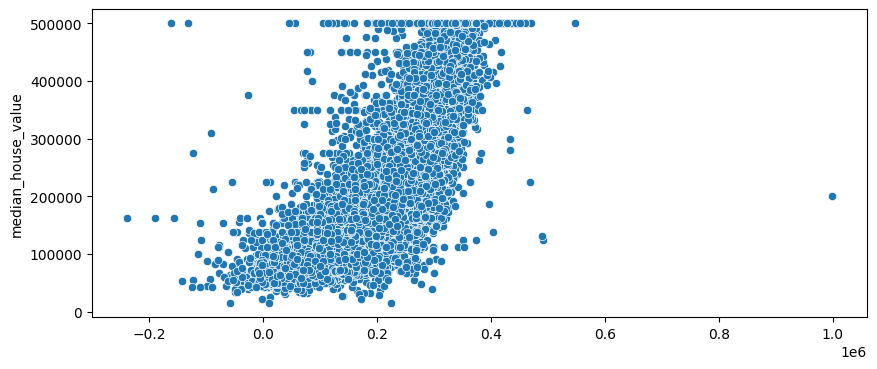

```python
plt.figure(figsize=(10, 4))

sns.scatterplot(x=y_predito_regressao_linear, y=y_treino);
```

🚨 Este é um exemplo de um modelo com **subajuste**

- do conjunto de dados de treinamento 🏋️‍♂️ 🚨

```python
from sklearn.metrics import root_mean_squared_error

regressao_linear_rmse = root_mean_squared_error(y_treino, y_predito_regressao_linear)
regressao_linear_rmse
```

```
71345.72408942516
```

👉 Quando isso acontece?

- as características/variáveis não fornecem informações suficientes
  - para fazer boas previsões;
  - ℹ️ solução: adicionar mais características 🤔
- o modelo não é bom o suficiente;
  - ℹ️ solução: usar um modelo mais complexo ✅
- o modelo tem restrições (regularização).
  - ℹ️ solução: regularizar o modelo ❌

👉 Vamos usar uma Árvore de Decisão,

- capaz de encontrar relações não lineares complexas nos dados.

### Árvore de Decisão 🌴

Treinaremos, agora, um modelo de **Árvore de Decisão**

#### Treinamento 🏋️‍♂️

```python
from sklearn.tree import DecisionTreeRegressor

arvore_decisao = make_pipeline(preprocessing, DecisionTreeRegressor())
arvore_decisao.fit(X_treino,  y_treino)
```

```
Pipeline(steps=[('columntransformer',
                 ColumnTransformer(remainder=Pipeline(steps=[('simpleimputer',
                                                              SimpleImputer(strategy='median')),
                                                             ('standardscaler',
                                                              StandardScaler())]),
                                   transformers=[('cat',
                                                  Pipeline(steps=[('simpleimputer',
                                                                   SimpleImputer(strategy='most_frequent')),
                                                                  ('onehotencoder',
                                                                   OneHotEncoder(handle_unknown='ignore'))]),
                                                  <sklearn.compose._column_t...
                                                 ('people_per_house',
                                                  Pipeline(steps=[('simpleimputer',
                                                                   SimpleImputer(strategy='median')),
                                                                  ('functiontransformer',
                                                                   FunctionTransformer(feature_names_out=<function feature_names_out at 0x1179f7560>,
                                                                                       func=<function column_ratio at 0x1179f7c40>)),
                                                                  ('standardscaler',
                                                                   StandardScaler())]),
                                                  ['population',
                                                   'households'])])),
                ('decisiontreeregressor', DecisionTreeRegressor())])
```

#### Predição 🔮

Vamos tentar usar o modelo de Árvore de Decisão no subconjunto de dados de treinamento 🏋️‍♂️

```python
y_predito_arvore_decisao = arvore_decisao.predict(X_treino)
y_predito_arvore_decisao
```

```
array([324400., 300000., 225000., ..., 225800.,  69800., 500001.],
      shape=(16512,))
```

#### Avaliação 🧪

As previsões (em contraste com os valores reais) apresentam a pura perfeição. 🤯

```python
comparar_real_com_predito("arvore_decisao", y_treino,
                          y_predito_arvore_decisao).head()
```

|  | median_house_value | arvore_decisao_predicao | erro |
| --- | --- | --- | --- |
| 7400 | 324400.0 | 324400.0 | 0% |
| 18611 | 300000.0 | 300000.0 | 0% |
| 12329 | 225000.0 | 225000.0 | 0% |
| 943 | 58300.0 | 58300.0 | 0% |
| 55 | 83100.0 | 83100.0 | 0% |

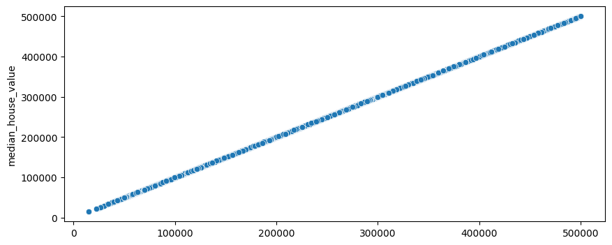

```python
plt.figure(figsize=(10, 4))

sns.scatterplot(x=y_predito_arvore_decisao, y=y_treino);
```

🚨 Este é um exemplo de um modelo com **sobreajuste**

- do conjunto de dados de treinamento 🏋️‍♂️ 🚨

```python
from sklearn.metrics import root_mean_squared_error

arvore_rmse = root_mean_squared_error(y_treino, y_predito_arvore_decisao)
arvore_rmse
```

```
0.0
```

Não podemos tocar no conjunto de testes 🧪 até que esteja pronto

- para lançar um modelo confiável,
- então precisamos utilizar parte do subconjunto de dados de treinamento 🏋️‍♂️
  - para treinar 💪; e outra parte
  - para validar o modelo 👊

Como?

1. Usar o método `train_test_split` para dividir
- o subconjunto de dados de treinamento 🏋️‍♂️ em
  - um subconjunto menor de treinamento 💪;
  - e um subconjunto de validação 👊,
3. em seguida, treinar seus modelos com
   - o subconjunto menor 💪; e
   - avaliá-los com o subconjunto de validação 👊.

👉 Uma ótima alternativa é utilizar o recurso da **validação cruzada** do Scikit-Learn

- principalmente se o conjunto de dados for pequeno.

[figure not shown]

#### Validação Cruzada

Vejamos como funciona a validação cruzada $k$-fold:

- divide aleatoriamente o subconjunto de dados de treinamento 🏋️‍♂️ em
  - $k$ subconjuntos distintos chamados de dobras (*folds*);
- treina e avalia o modelo de Aprendizado de Máquina $k$ vezes,
  - escolhendo 1 dobra (*fold*) diferente a cada uma delas,
  - para avaliação; e
  - treinando nas outras $k-1$ dobras.

[figure not shown]

Lembre-se que definimos que nossa medida de desempenho é $$RMSE(X, h) = \sqrt{\frac{1}{m} \displaystyle\sum_{i=1}^{m} \left(h(x_i) - y_i\right)^2},$$ em que $h$ é o nosso modelo de aprendizado de máquina **Árvore de Decisão**.

👉 As medidas de desempenho figuram na lista de [scoring_string_names](https://scikit-learn.org/stable/modules/model_evaluation.html#string-name-scorers).

```python
from sklearn.model_selection import cross_val_score

escores = cross_val_score(arvore_decisao, X_treino, y_treino,
                          scoring="neg_root_mean_squared_error", cv=3)
escores.mean()
```

```
np.float64(-72273.83131171668)
```

👉 a função de utilidade tem sinal negativo. Isso ocorre porque...

- validação cruzada usa função de utilidade
  - quanto mais alta, melhor
- em vez de uma função de custo
  - quanto mais baixa, melhor

Uma vez que $C(X) = -U(X)$, temos que $\min C(x) = \max U(X)$, sendo

- $C(X)$ a função de custo; e
- $U(X)$ a função utilidade.

Por isso, nosso $RMSE $ é a média de $-escores$.

```python
arvore_rmse = -escores
arvore_rmse.mean()
```

```
np.float64(72273.83131171668)
```

Usando um subconjunto de validação não visto pelo treinamento,

- a Árvore de Decisão não tem uma avaliação tão boa quanto antes ($RMSE = 0$)

👉 curiosidade: a validação cruzada permite que obtenhamos

- uma estimativa do desempenho do seu modelo; e
- uma medida da precisão dessa estimativa (desvio padrão).

```python
tabela_comparativa = pd.DataFrame(
    {"arvore":
         [f"{arvore_rmse.mean():.2f} ± {arvore_rmse.std():.2f}"]
    },
    index=["RMSE"])

tabela_comparativa
```

|  | arvore |
| --- | --- |
| RMSE | 72273.83 ± 1089.00 |

👉 Não teríamos essa informação se utilizássemos apenas um conjunto de validação.

- No entanto, a validação cruzada treina o modelo várias vezes,
  - demorando muito mais tempo,
- então nem sempre estamos dispostos a obter o desvio padrão
  - ao custo de investir muito mais tempo.

```python
from sklearn.model_selection import cross_val_score

escores = cross_val_score(regressao_linear, X_treino, y_treino,
                          scoring="neg_root_mean_squared_error", cv=3)
regressao_linear_rmse = -escores

regressao_linear_rmse.mean()
```

```
np.float64(71863.96616123628)
```

👉 veja o intervalo de score

- para cada um dos algoritmos de aprendizado de máquina que usamos.

```python
tabela_comparativa['regressao_linear'] = \
    [f"{regressao_linear_rmse.mean():.2f} ± {regressao_linear_rmse.std():.2f}"]
tabela_comparativa = tabela_comparativa[['regressao_linear', 'arvore']]

tabela_comparativa
```

|  | regressao_linear | arvore |
| --- | --- | --- |
| RMSE | 71863.97 ± 1918.70 | 72273.83 ± 1089.00 |

### Agrupamento (*Ensemble*) 🌌

Outro ajuste fino é combinar modelos de melhor desempenho.

- O grupo (ou *ensemble*) geralmente será superior ao melhor modelo individual
- e.g., Florestas Aleatórias funcionam melhor do que
  - as Árvores de Decisão individuais em que se baseiam.

#### Pipeline 🪈

Treinaremos, por último, um modelo de **Floresta Aleatória**

```python
from sklearn.ensemble import RandomForestRegressor

floresta = make_pipeline(preprocessing, RandomForestRegressor())
floresta
```

```
Pipeline(steps=[('columntransformer',
                 ColumnTransformer(remainder=Pipeline(steps=[('simpleimputer',
                                                              SimpleImputer(strategy='median')),
                                                             ('standardscaler',
                                                              StandardScaler())]),
                                   transformers=[('cat',
                                                  Pipeline(steps=[('simpleimputer',
                                                                   SimpleImputer(strategy='most_frequent')),
                                                                  ('onehotencoder',
                                                                   OneHotEncoder(handle_unknown='ignore'))]),
                                                  <sklearn.compose._column_t...
                                                 ('people_per_house',
                                                  Pipeline(steps=[('simpleimputer',
                                                                   SimpleImputer(strategy='median')),
                                                                  ('functiontransformer',
                                                                   FunctionTransformer(feature_names_out=<function feature_names_out at 0x1179f7560>,
                                                                                       func=<function column_ratio at 0x1179f7c40>)),
                                                                  ('standardscaler',
                                                                   StandardScaler())]),
                                                  ['population',
                                                   'households'])])),
                ('randomforestregressor', RandomForestRegressor())])
```

#### Validação Cruzada

```python
from sklearn.model_selection import cross_val_score

escores = cross_val_score(floresta, X_treino, y_treino,
                          scoring="neg_root_mean_squared_error", cv=3)
floresta_rmse = -escores
floresta_rmse
```

```
array([49826.68200847, 52445.75685491, 51656.496394  ])
```

👉 veja o intervalo de score

- para cada um dos algoritmos de aprendizado de máquina que usamos.

```python
tabela_comparativa['floresta'] = \
    [f"{floresta_rmse.mean():.2f} ± {floresta_rmse.std():.2f}"]

tabela_comparativa
```

|  | regressao_linear | arvore | floresta |
| --- | --- | --- | --- |
| RMSE | 71863.97 ± 1918.70 | 72273.83 ± 1089.00 | 51309.65 ± 1097.00 |

👉 Florestas Aleatórias parecem muito promissoras

- ainda que **sobreajuste** não esteja descartado

🚨 Devemos experimentar muitos outros modelos,

- de várias categorias de algoritmos de Aprendizado de Máquina,
- com o objetivo de selecionar alguns modelos promissores (de dois a cinco).

## Aperfeiçoamento ❤️‍🩹

Chegamos a uma lista (restrita) de 3 modelos promissores.

👉 Vamos ver algumas maneiras de realizar o ajuste fino em um modelo.

[figure not shown]

👉 Maneiras de realizar o ajuste fino em um modelo de aprendizado de Máquina:

- **manualmente**: alterar os hiperparâmetros
  - até encontrar uma combinação ótima de valores 😔
- **automaticamente**: acionar o `GridSearchCV` do Scikit-Learn
  - para efetuar a busca pra gente 😁

### Busca em Grade

Na busca em grade, passamos os hiperparâmetros que desejamos

- que a busca experimente
  - a busca utilizará a validação cruzada
    - para avaliar todas as possíveis combinações de hiperparâmetros; e
  - a melhor escolha (de acordo com a medida de desempenho)
    - será retornada pela busca.

[figure not shown]

👉 Lembre-se que podemos acessar qualquer hiperparâmetro

- de qualquer estimador de um pipeline
  - mesmo se o estimador está nas "profundezas"
    - de vários *pipelines*; e
    - *column transformers*.

**Exemplo**

👉 Quando o Scikit-Learn vê "randomforestregressor__max_features",

- esta é uma referência para
  - hiperparâmetro `max_features`
  - do modelo de Aprendizado de Máquina `RandomForestRegressor`

```python
str([k for k in floresta.get_params().keys()
     if 'randomforestregressor' in k][:10])
```

```
"['randomforestregressor', 'randomforestregressor__bootstrap', 'randomforestregressor__ccp_alpha', 'randomforestregressor__criterion', 'randomforestregressor__max_depth', 'randomforestregressor__max_features', 'randomforestregressor__max_leaf_nodes', 'randomforestregressor__max_samples', 'randomfore…
```

Um dos parâmetros da busca em grade (`GridSearchCV`) é o `param_grid`,

- uma lista de dicionários, em que
  - para cada dicionário da lista,
    - todas as combinações de hiperparâmetros do dicionário
    - serão testadas.

**Exemplo**.

Realizaremos uma busca em grade, em que

- para dicionário da lista, selecionamos
  - para cada valor do hiperparâmetro `max_features`,
  - para cada valor do hiperparâmetro `max_depth`,
  - o par será usado como hiperparâmetros
    - no treinamento do `RandomForestRegressor`.

Portanto, realizaremos $1 \times 3 \times 3 = 9$ combinações

- de valores para os hiperparâmetros `max_depth` e `max_features`.

```python
param_grid = [{'randomforestregressor__max_features': [4, 6, 8],
                'randomforestregressor__max_depth': [4, 8, 16]}]
```

Uma vez que a busca em grade abaixo utiliza $3$ dobras para a validação cruzada,

- realizaremos o treinamento de $9 \times 3 = 27$ Florestas Aleatórias,
- para recuperar a Floresta Aleatória que tem melhor desempenho.

```python
%%time
from sklearn.model_selection import GridSearchCV

busca_grade = GridSearchCV(floresta, param_grid, cv=3,
                           scoring='neg_root_mean_squared_error')

busca_grade.fit(X_treino, y_treino)
```

```
CPU times: user 40.4 s, sys: 153 ms, total: 40.6 s
Wall time: 40.8 s
```

```
GridSearchCV(cv=3,
             estimator=Pipeline(steps=[('columntransformer',
                                        ColumnTransformer(remainder=Pipeline(steps=[('simpleimputer',
                                                                                     SimpleImputer(strategy='median')),
                                                                                    ('standardscaler',
                                                                                     StandardScaler())]),
                                                          transformers=[('cat',
                                                                         Pipeline(steps=[('simpleimputer',
                                                                                          SimpleImputer(strategy='most_frequent')),
                                                                                         ('onehotencoder',
                                                                                          OneHotEncoder(handle_unknown='ignore'))]...
                                                                                          FunctionTransformer(feature_names_out=<function feature_names_out at 0x1179f7560>,
                                                                                                              func=<function column_ratio at 0x1179f7c40>)),
                                                                                         ('standardscaler',
                                                                                          StandardScaler())]),
                                                                         ['population',
                                                                          'households'])])),
                                       ('randomforestregressor',
                                        RandomForestRegressor())]),
             param_grid=[{'randomforestregressor__max_depth': [4, 8, 16],
                          'randomforestregressor__max_features': [4, 6, 8]}],
             scoring='neg_root_mean_squared_error')
```

Pode demorar muito,

- mas quando terminar obteremos a melhor combinação de parâmetros.

```python
busca_grade.best_params_
```

```
{'randomforestregressor__max_depth': 16,
 'randomforestregressor__max_features': 6}
```

Podemos obter diretamente o melhor estimador.

```python
busca_grade.best_estimator_
```

```
Pipeline(steps=[('columntransformer',
                 ColumnTransformer(remainder=Pipeline(steps=[('simpleimputer',
                                                              SimpleImputer(strategy='median')),
                                                             ('standardscaler',
                                                              StandardScaler())]),
                                   transformers=[('cat',
                                                  Pipeline(steps=[('simpleimputer',
                                                                   SimpleImputer(strategy='most_frequent')),
                                                                  ('onehotencoder',
                                                                   OneHotEncoder(handle_unknown='ignore'))]),
                                                  <sklearn.compose._column_t...
                                                  Pipeline(steps=[('simpleimputer',
                                                                   SimpleImputer(strategy='median')),
                                                                  ('functiontransformer',
                                                                   FunctionTransformer(feature_names_out=<function feature_names_out at 0x1179f7560>,
                                                                                       func=<function column_ratio at 0x1179f7c40>)),
                                                                  ('standardscaler',
                                                                   StandardScaler())]),
                                                  ['population',
                                                   'households'])])),
                ('randomforestregressor',
                 RandomForestRegressor(max_depth=16, max_features=6))])
```

As pontuações de avaliação também estão disponíveis.

```python
df_busca_grade = avaliar_busca(busca_grade.cv_results_)
df_busca_grade.head()
```

|  | max_depth | max_features | split0 | split1 | split2 | mean_test_score | std_test_score |
| --- | --- | --- | --- | --- | --- | --- | --- |
| 7 | 16 | 6 | 48445.039866 | 51627.477314 | 51006.057388 | 50359.524856 | 1377.311454 |
| 8 | 16 | 8 | 48650.155669 | 51959.707563 | 50629.655246 | 50413.172826 | 1359.762703 |
| 6 | 16 | 4 | 48679.122131 | 52145.786212 | 50687.742438 | 50504.216927 | 1421.196954 |
| 4 | 8 | 6 | 53816.453856 | 56734.610159 | 56044.977011 | 55532.013675 | 1245.326621 |
| 5 | 8 | 8 | 53732.691165 | 57092.525874 | 56119.645708 | 55648.287582 | 1411.560881 |

Vamos avaliar o resultado deste treinamento com busca em grade.

```python
tabela_comparativa['floresta_busca_grade'] = \
    [f"{df_busca_grade.iloc[0]["mean_test_score"]:.2f} ± {df_busca_grade.iloc[0]["std_test_score"]:.2f}"]

tabela_comparativa
```

|  | regressao_linear | arvore | floresta | floresta_busca_grade |
| --- | --- | --- | --- | --- |
| RMSE | 71863.97 ± 1918.70 | 72273.83 ± 1089.00 | 51309.65 ± 1097.00 | 50359.52 ± 1377.31 |

### Busca Aleatorizada

A busca em grade é boa quando exploramos poucas combinações.

- a busca aleatorizada (`RandomizedSearchCV`) é boa
  - quando precisamos explorar muitas combinações.

O mecanismo de funcionamento é semelhante, mas

- em vez de tentar todas as combinações possíveis,
- em cada iteração,
  - um valor aleatório é selecionado para cada hiperparâmetro,
  - até alcançar um determinado número de combinações aleatórias.

[figure not shown]

Realizaremos uma busca aleatorizada a partir de duas distribuições:

Dessa forma,

- para cada valor amostrado da distribuição de `max_features`, e
- para cada valor amostrado da distribuição de `max_depth`,
- o par será usado como hiperparâmetros
  - no treinamento do `RandomForestRegressor`...

```python
from scipy.stats import randint

param_distribs = {'randomforestregressor__max_features':
                  randint(low=4, high=16),
                  'randomforestregressor__max_depth':
                  randint(low=4, high=16)}
```

... até que 10 iterações sejam alcançadas.

Uma vez que a busca aleatorizada abaixo utiliza $3$ dobras para a validação cruzada,

- e a quantidade máxima de iterações/treinamentos
  - do `RandomForestRegressor` é 10,
- realizaremos o treinamento de $10 \times 3 = 30$ Florestas Aleatórias,
- para recuperar a Floresta Aleatória que tem melhor desempenho.

```python
%%time
from sklearn.model_selection import RandomizedSearchCV

busca_aleatorizada = RandomizedSearchCV(
    floresta, param_distribs, n_iter=10, cv=3,
    scoring='neg_root_mean_squared_error')

busca_aleatorizada.fit(X_treino, y_treino)
```

```
CPU times: user 52.8 s, sys: 469 ms, total: 53.3 s
Wall time: 55.1 s
```

```
RandomizedSearchCV(cv=3,
                   estimator=Pipeline(steps=[('columntransformer',
                                              ColumnTransformer(remainder=Pipeline(steps=[('simpleimputer',
                                                                                           SimpleImputer(strategy='median')),
                                                                                          ('standardscaler',
                                                                                           StandardScaler())]),
                                                                transformers=[('cat',
                                                                               Pipeline(steps=[('simpleimputer',
                                                                                                SimpleImputer(strategy='most_frequent')),
                                                                                               ('onehotencoder',
                                                                                                OneHotEncoder(handle_unknown='igno...
                                                                                'households'])])),
                                             ('randomforestregressor',
                                              RandomForestRegressor())]),
                   param_distributions={'randomforestregressor__max_depth': <scipy.stats._distn_infrastructure.rv_discrete_frozen object at 0x117b81810>,
                                        'randomforestregressor__max_features': <scipy.stats._distn_infrastructure.rv_discrete_frozen object at 0x115932510>},
                   scoring='neg_root_mean_squared_error')
```

As pontuações de avaliação também estão disponíveis.

```python
df_busca_aleatorizada = avaliar_busca(busca_aleatorizada.cv_results_)
df_busca_aleatorizada.head()
```

|  | max_depth | max_features | split0 | split1 | split2 | mean_test_score | std_test_score |
| --- | --- | --- | --- | --- | --- | --- | --- |
| 5 | 14 | 4 | 48850.288437 | 52830.670510 | 51258.291421 | 50979.750122 | 1636.876966 |
| 2 | 9 | 15 | 53524.559105 | 55868.963230 | 55247.938831 | 54880.487056 | 991.740316 |
| 6 | 7 | 10 | 56258.805630 | 58631.655871 | 57985.241390 | 57625.234297 | 1001.601516 |
| 0 | 7 | 6 | 56352.746109 | 59154.638200 | 57769.857448 | 57759.080585 | 1143.893039 |
| 8 | 7 | 15 | 56854.089085 | 58964.723510 | 58760.297647 | 58193.036748 | 950.450109 |

Vamos avaliar o resultado deste treinamento com busca aleatorizada.

```python
tabela_comparativa['floresta_busca_aleatorizada'] = [f"{df_busca_aleatorizada.iloc[0]["mean_test_score"]:.2f} ± {df_busca_aleatorizada.iloc[0]["std_test_score"]:.2f}"]
tabela_comparativa
```

|  | regressao_linear | arvore | floresta | floresta_busca_grade | floresta_busca_aleatorizada |
| --- | --- | --- | --- | --- | --- |
| RMSE | 71863.97 ± 1918.70 | 72273.83 ± 1089.00 | 51309.65 ± 1097.00 | 50359.52 ± 1377.31 | 50979.75 ± 1636.88 |

### 🗞️ Extra! Distribuições para Hiperparâmetros

Como escolher a distribuição amostral para um hiperparâmetro?

[output not shown]

### 🗞️ Extra! Buscas *Halving*

Scikit-Learn disponibiliza as classes de busca por hiperparâmetros

- `HalvingRandomSearchCV`; e
- `HalvingGridSearchCV`.

```python
from sklearn.experimental import enable_halving_search_cv
```

👉 Seus objetivos são usar os recursos computacionais mais eficientemente,

- para treinar mais rápido; ou
- para explorar um espaço maior de hiperparâmetros.

#### Busca em Grade com *Halving*

```python
%%time
from sklearn.model_selection import HalvingGridSearchCV

busca_halving_em_grade = HalvingGridSearchCV(
    floresta, param_grid, cv=3,
    scoring='neg_root_mean_squared_error')
busca_halving_em_grade.fit(X_treino, y_treino)
```

```
CPU times: user 21.9 s, sys: 233 ms, total: 22.2 s
Wall time: 23.1 s
```

```
HalvingGridSearchCV(cv=3,
                    estimator=Pipeline(steps=[('columntransformer',
                                               ColumnTransformer(remainder=Pipeline(steps=[('simpleimputer',
                                                                                            SimpleImputer(strategy='median')),
                                                                                           ('standardscaler',
                                                                                            StandardScaler())]),
                                                                 transformers=[('cat',
                                                                                Pipeline(steps=[('simpleimputer',
                                                                                                 SimpleImputer(strategy='most_frequent')),
                                                                                                ('onehotencoder',
                                                                                                 OneHotEncoder(handle_unknown='ign...
                                                                                                 FunctionTransformer(feature_names_out=<function feature_names_out at 0x1179f7560>,
                                                                                                                     func=<function column_ratio at 0x1179f7c40>)),
                                                                                                ('standardscaler',
                                                                                                 StandardScaler())]),
                                                                                ['population',
                                                                                 'households'])])),
                                              ('randomforestregressor',
                                               RandomForestRegressor())]),
                    param_grid=[{'randomforestregressor__max_depth': [4, 8, 16],
                                 'randomforestregressor__max_features': [4, 6,
                                                                         8]}],
                    scoring='neg_root_mean_squared_error')
```

```python
df_busca_halving_em_grade = avaliar_busca(
    busca_halving_em_grade.cv_results_)
tabela_comparativa['floresta_busca_halving_em_grade'] = \
    [f"{df_busca_halving_em_grade.iloc[0]["mean_test_score"]:.2f} ± {df_busca_halving_em_grade.iloc[0]["std_test_score"]:.2f}"]
```

```python
tabela_comparativa
```

|  | regressao_linear | arvore | floresta | floresta_busca_grade | floresta_busca_aleatorizada | floresta_busca_halving_em_grade |
| --- | --- | --- | --- | --- | --- | --- |
| RMSE | 71863.97 ± 1918.70 | 72273.83 ± 1089.00 | 51309.65 ± 1097.00 | 50359.52 ± 1377.31 | 50979.75 ± 1636.88 | 50165.12 ± 1421.52 |

#### Busca Aleatória com *Halving*

```python
%%time
from sklearn.model_selection import HalvingRandomSearchCV

busca_halving_aleatorizada = HalvingRandomSearchCV(
    floresta, param_distribs, cv=3,
    scoring='neg_root_mean_squared_error')
busca_halving_aleatorizada.fit(X_treino, y_treino)
```

```
CPU times: user 13min 4s, sys: 6.01 s, total: 13min 10s
Wall time: 13min 22s
```

```
HalvingRandomSearchCV(cv=3,
                      estimator=Pipeline(steps=[('columntransformer',
                                                 ColumnTransformer(remainder=Pipeline(steps=[('simpleimputer',
                                                                                              SimpleImputer(strategy='median')),
                                                                                             ('standardscaler',
                                                                                              StandardScaler())]),
                                                                   transformers=[('cat',
                                                                                  Pipeline(steps=[('simpleimputer',
                                                                                                   SimpleImputer(strategy='most_frequent')),
                                                                                                  ('onehotencoder',
                                                                                                   OneHotEncoder(handle_unknown='i...
                                                                                   'households'])])),
                                                ('randomforestregressor',
                                                 RandomForestRegressor())]),
                      param_distributions={'randomforestregressor__max_depth': <scipy.stats._distn_infrastructure.rv_discrete_frozen object at 0x117b81810>,
                                           'randomforestregressor__max_features': <scipy.stats._distn_infrastructure.rv_discrete_frozen object at 0x115932510>},
                      scoring='neg_root_mean_squared_error')
```

```python
df_busca_halving_aleatorizada = avaliar_busca(
    busca_halving_aleatorizada.cv_results_)
tabela_comparativa['floresta_busca_halving_aleatorizada'] = \
    [f"{df_busca_halving_aleatorizada.iloc[0]["mean_test_score"]:.2f} ± {df_busca_halving_aleatorizada.iloc[0]["std_test_score"]:.2f}"]
```

```python
tabela_comparativa
```

|  | regressao_linear | arvore | floresta | floresta_busca_grade | floresta_busca_aleatorizada | floresta_busca_halving_em_grade | floresta_busca_halving_aleatorizada |
| --- | --- | --- | --- | --- | --- | --- | --- |
| RMSE | 71863.97 ± 1918.70 | 72273.83 ± 1089.00 | 51309.65 ± 1097.00 | 50359.52 ± 1377.31 | 50979.75 ± 1636.88 | 50165.12 ± 1421.52 | 51566.22 ± 1349.83 |

### Interprete Modelos e Erros

Muitas vezes, obteremos boas ideias sobre o problema

- ao inspecionar os melhores modelos.

O `RandomForestRegressor` pode indicar a importância relativa de cada atributo

- para fazer previsões precisas.

"**Feature importance** estimates how important a feature is for the model. It is usually done using permutation importance,

- which measures the performance decrease when it the feature value randomly shuffled across all samples."

👉 Primeiro, buscamos os nomes das características/variáveis.

```python
variaveis = busca_grade.\
    best_estimator_["columntransformer"].\
    get_feature_names_out()
variaveis
```

```
array(['cat__ocean_proximity_<1H OCEAN', 'cat__ocean_proximity_INLAND',
       'cat__ocean_proximity_ISLAND', 'cat__ocean_proximity_NEAR BAY',
       'cat__ocean_proximity_NEAR OCEAN', 'log__total_bedrooms',
       'log__total_rooms', 'log__population', 'log__households',
       'log__median_income', 'bedrooms__ratio', 'rooms_per_house__ratio',
       'people_per_house__ratio', 'remainder__longitude',
       'remainder__latitude', 'remainder__housing_median_age'],
      dtype=object)
```

👉 Depois, buscamos as pontuações de importância correspondentes.

```python
importancias = busca_grade.\
    best_estimator_["randomforestregressor"].\
    feature_importances_
importancias
```

```
array([1.48998583e-02, 1.53293720e-01, 2.28996175e-04, 3.20204333e-03,
       6.01613607e-03, 1.50042713e-02, 1.54595262e-02, 1.59963959e-02,
       1.45805367e-02, 3.28187879e-01, 7.83830870e-02, 6.20173152e-02,
       1.07796744e-01, 7.70736358e-02, 6.86042740e-02, 3.92555814e-02])
```

👉 Agora, mostramos as características/variáveis em ordem descrescente de importância

```python
df_importancia = pd.DataFrame({"variaveis": variaveis,
                               "importancia": importancias}).\
    sort_values('importancia', ascending=False)
df_importancia.head()
```

|  | variaveis | importancia |
| --- | --- | --- |
| 9 | log__median_income | 0.328188 |
| 1 | cat__ocean_proximity_INLAND | 0.153294 |
| 12 | people_per_house__ratio | 0.107797 |
| 10 | bedrooms__ratio | 0.078383 |
| 13 | remainder__longitude | 0.077074 |

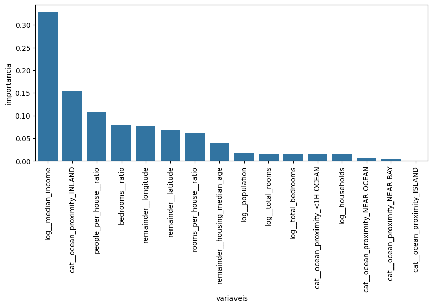

```python
fig = plt.figure(figsize=(10, 4))
plt.xticks(rotation=90)
sns.barplot(data=df_importancia, x="variaveis", y="importancia");
```

Podemos tentar descartar algumas das características/variáveis menos úteis.

- e.g., apenas a categoria `INLAND` da característica/variável `ocean_proximity`
  - parece ser útil.

### Avalie seu Modelo

Agora é a hora de avaliar o modelo final no conjunto de teste.

#### Teste 👍

```python
X_teste = teste_estratificado.drop(columns=["median_house_value"])
y_teste = teste_estratificado['median_house_value']
```

#### Predição 🔮

Vamos tentar usar o melhor modelo encontrado na busca

- no subconjunto de dados de teste 👍

```python
modelo_escolhido = busca_grade.best_estimator_
y_predito_melhor_modelo = modelo_escolhido.predict(X_teste)
```

#### Avaliação 🧪

As previsões (em contraste com os valores reais) apresentam

- um melhor cenário de erros. 😊

```python
comparar_real_com_predito("melhor_modelo", y_teste, y_predito_melhor_modelo).head()
```

|  | median_house_value | melhor_modelo_predicao | erro |
| --- | --- | --- | --- |
| 11725 | 153700.0 | 171825.832629 | 12% |
| 5771 | 233300.0 | 316906.192457 | 36% |
| 12057 | 82500.0 | 87894.786961 | 7% |
| 14805 | 316900.0 | 267827.197474 | -15% |
| 12321 | 162700.0 | 171493.859991 | 5% |

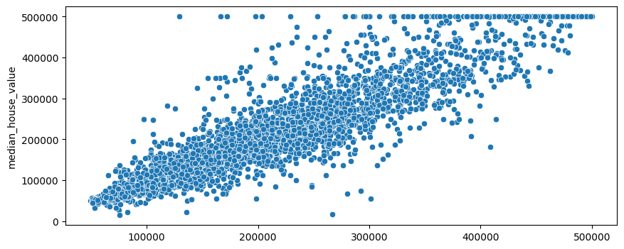

```python
plt.figure(figsize=(10, 4))

sns.scatterplot(x=y_predito_melhor_modelo, y=y_teste);
```

## Implantar 📦, Monitorar 🖥️ e Manter 🫡

[figure not shown]

### Salvar 💾

Precisamos preparar sua solução para a produção.

```python
import os

if not os.path.exists("producao"):
    os.makedirs("producao")
```

Para salvar o modelo, podemos usar a biblioteca `joblib`.

```python
import joblib

joblib.dump(modelo_escolhido, "producao/modelo.pkl")
```

```
['producao/modelo.pkl']
```

Alternativamente, podemos usar o `pickle`.

```python
from pickle import dump, HIGHEST_PROTOCOL

with open("producao/modelo.pkl", "wb") as f:
    dump(modelo_escolhido, f, protocol=HIGHEST_PROTOCOL)
```

### Carregar 🔋

Uma vez que o seu modelo foi transferido para o ambiente de produção...

... podemos carregar o modelo e usá-lo.

🚨 só conseguimos usar o modelo se importamos

- qualquer classe; ou
- função que o modelo use.

```python
def column_ratio(X):
    return X[:, [0]] / X[:, [1]]
def feature_names_out(function_transformer, feature_names_in):
    return ["ratio"]
```

para então carregar o modelo usando `joblib` e usá-lo para realizar predições

```python
import joblib

modelo_recarregado = joblib.load("producao/modelo.pkl")
```

```python
y_preditivo_modelo_recarregado = modelo_recarregado.predict(X_teste)
```

```python
comparar_real_com_predito("modelo_recarregado", y_teste,
                          y_preditivo_modelo_recarregado).head()
```

|  | median_house_value | modelo_recarregado_predicao | erro |
| --- | --- | --- | --- |
| 11725 | 153700.0 | 171825.832629 | 12% |
| 5771 | 233300.0 | 316906.192457 | 36% |
| 12057 | 82500.0 | 87894.786961 | 7% |
| 14805 | 316900.0 | 267827.197474 | -15% |
| 12321 | 162700.0 | 171493.859991 | 5% |

[figure not shown]

### Saiba Mais 👩‍🏫

```python
YouTubeVideo(id="OejCJL2EC3k", width="100%")
```

[video not shown]

`Executem todo este caderno 🙂`